# Will I stay or will I go?

Stand-by flying, holiday season, full flights, mild snowstorms, a relaxing lounge with fake trees and a green carpet. Only insights into real data and multi-factor probabilistic analysis might be able to give a valid prediction of whether I will manage to catch a flight tomorrow.

Since I don't have all that data, I'll simply fall back into what humans are so good at: **superstition** 😉

So here's my completely random analysis of some random corpora, to find out with high certainty whether or not I'll leave this airport tomorrow.

Say hello to the text-based **flight oracle**!

## Preparing the oracle for service

```python
import nltk
from nltk.book import *
```

```
*** Introductory Examples for the NLTK Book ***
Loading text1, ..., text9 and sent1, ..., sent9
Type the name of the text or sentence to view it.
Type: 'texts()' or 'sents()' to list the materials.
text1: Moby Dick by Herman Melville 1851
text2: Sense and Sensibility by Jane Austen 1811
text3: The Book of Genesis
text4: Inaugural Address Corpus
text5: Chat Corpus
text6: Monty Python and the Holy Grail
text7: Wall Street Journal
text8: Personals Corpus
text9: The Man Who Was Thursday by G . K . Chesterton 1908
```

```python
all_texts = [text1, text2, text3, text4, text5, text6, text7, text8, text9]
```

## Calling the oracle

The oracle is ready. Let's see what it will tell us regarding my immediate future...

```
<Text: Moby Dick by Herman Melville 1851>
```

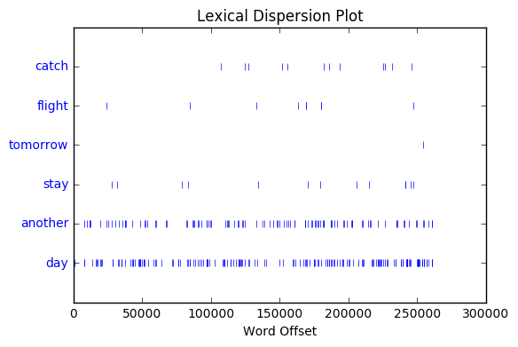

```
<Text: Sense and Sensibility by Jane Austen 1811>
```

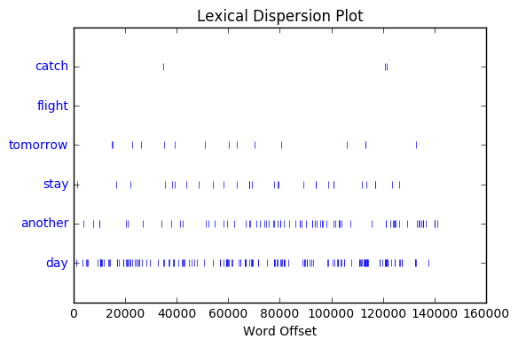

```
<Text: The Book of Genesis>
```

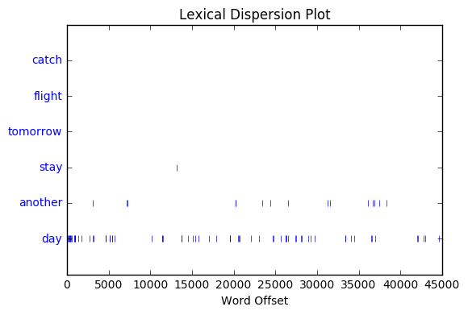

```
<Text: Inaugural Address Corpus>
```

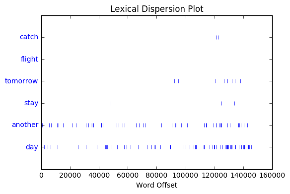

```
<Text: Chat Corpus>
```

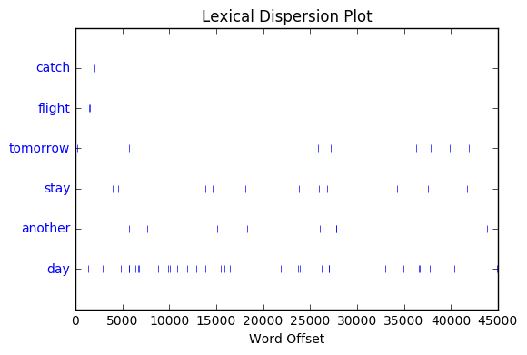

```
<Text: Monty Python and the Holy Grail>
```

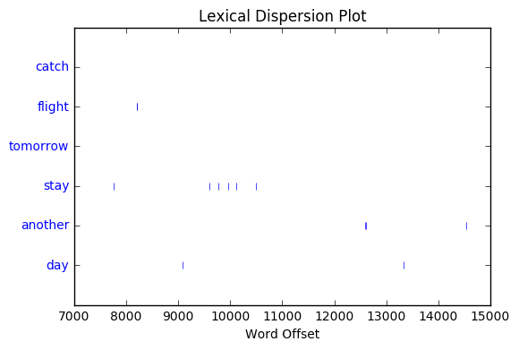

```
<Text: Wall Street Journal>
```

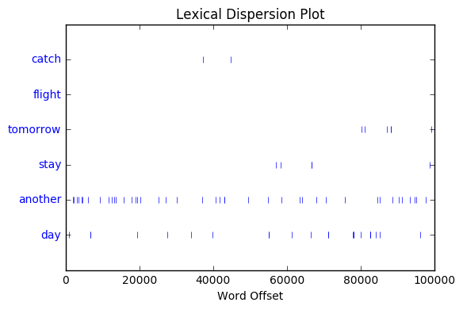

```
<Text: Personals Corpus>
```

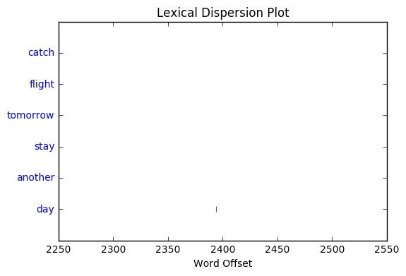

```
<Text: The Man Who Was Thursday by G . K . Chesterton 1908>
```

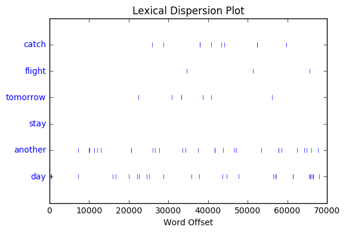

```python
for text in all_texts:
    print(text)
    text.dispersion_plot(["catch", "flight", "tomorrow", "stay", "another", "day"])
```

Ouch! Nearly all the oracle's voicings clearly favor the probability that I'll have to remain for another day!

Not looking good!

Only *The Man Who Was Thursday* seems to allot me at least *some* chance of success... This actually has an interesting aspect that might be able to tilt the tide in my favor after all!!

```python
from datetime import date
import calendar
today = date.today()
print(calendar.day_name[today.weekday()])
```

```
Wednesday
```

So while most voices of the flight oracle speak a clearly biased

> "NO"

*The Man Who Was **Thursday*** gives me a

> "you know... probably not. but MAYBE..."

And since tomorrow is **Thursday**, and since this whole thing is anyways staying in humanities great tradition of patter-finding and interpreting outcomes however we please - *DRUMROLL* - we have a result:

## Flight's gonna take me on! 😜

Yay!